# ANA 515 Visualizations Acitivity

Jaden Jefferson

4/15/2022

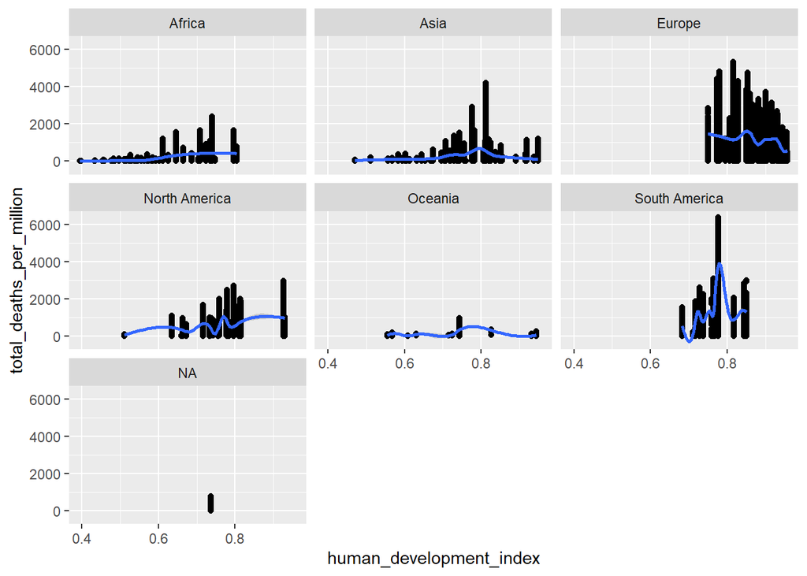

Then, what is the relationship between new vaccinations and new deaths.Looking at the graphic it does seem like as new vaccinations were administered the amount of deaths fail a lot. However, this can be due to repsonses by the government and how they handled the situation in different countries.

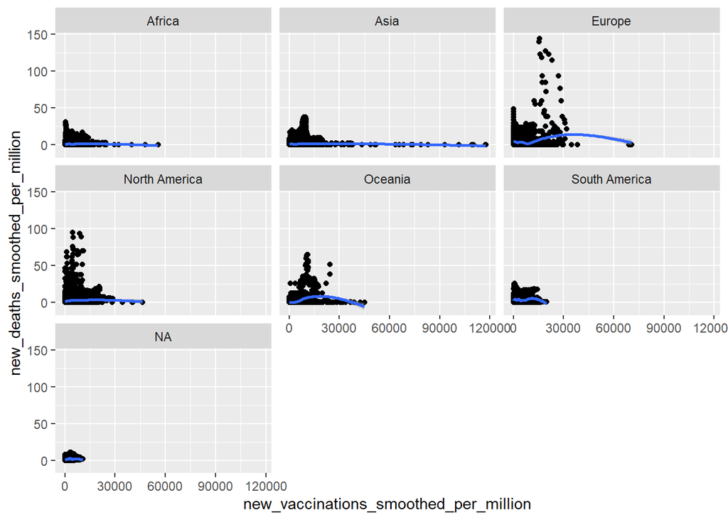

Under that same logic,does new vaccinations lead to less cases.In most cases it could be assumed yes. The per million is causing problems with the graphic. It is intersting that Oceania has their thing spike as vaccinations happened and that could be drilled down into for something interesting.

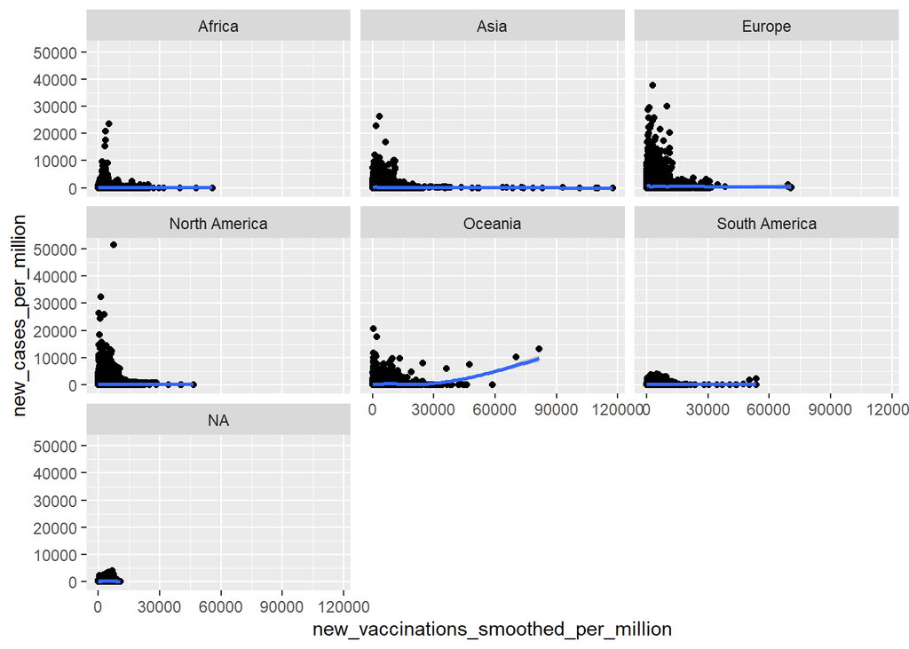